# Hw14

```r
library("readxl")
```

# Exercise 13.89

The parameter tested is $\mu_D$ where $\mu_D$ = $\mu_1$ –$\mu_2$

$$H_0: \mu_D \geq 0$$

$$H_1: \mu_D < 0$$
since we want to know if it takes less time after installing ABS

```r
read1389 = read_excel(path = "D:\\Xr13-89.xlsx")
attach(read1389)
```

To decide which variance test we should use:

$$H_0: \sigma_1^2/\sigma_2^2 = 1$$

$$H_1: \sigma_1^2/\sigma_2^2 \neq 1$$

```r
ftest1 = var.test(ABS,`non-ABS`,alternative = "two.sided", conf.level = 0.95)
print(ftest1)
```

```
##
##  F test to compare two variances
##
## data:  ABS and non-ABS
## F = 0.77337, num df = 7, denom df = 7, p-value = 0.7432
## alternative hypothesis: true ratio of variances is not equal to 1
## 95 percent confidence interval:
##  0.1548319 3.8629185
## sample estimates:
## ratio of variances
##          0.7733711
```

since p_value = 0.7432 > 0.05, there’s no sufficient evidence to infer that the population variances differ. It follows that we must apply the equal-variances t-test of $\mu_D$

```r
ttest1 = t.test(ABS,`non-ABS`,alternative = "less", mu = 0,paired = TRUE, var.equal = TRUE,conf.level = 0.95)
print(ttest1)
```

```
##
##  Paired t-test
##
## data:  ABS and non-ABS
## t = -2.198, df = 7, p-value = 0.03196
## alternative hypothesis: true difference in means is less than 0
## 95 percent confidence interval:
##         -Inf -0.02415435
## sample estimates:
## mean of the differences
##                  -0.175
```

since p_value = 0.03196 <0.05, there is sufficient evidence to support that it takes less time after installing ABS, which infers that it is better.

# Exercise 13.92

The parameter tested is $\mu_D$ where $\mu_D$ = $\mu_1$ –$\mu_2$

$$H_0: \mu_D \geq 0$$

$$H_1: \mu_D < 0$$
since we want to know if it takes less money expense after the exercise program

To decide which variance test we should use:

$$H_0: \sigma_1^2/\sigma_2^2 = 1$$

$$H_1: \sigma_1^2/\sigma_2^2 \neq 1$$

## a

```r
read1392 = read_excel(path = "D:\\Xr13-92.xlsx")
attach(read1392)
```

```r
ftest2 = var.test(After,Before,alternative = "two.sided", conf.level = 0.95)
print(ftest2)
```

```
##
##  F test to compare two variances
##
## data:  After and Before
## F = 1.2473, num df = 11, denom df = 11, p-value = 0.7204
## alternative hypothesis: true ratio of variances is not equal to 1
## 95 percent confidence interval:
##  0.3590798 4.3328674
## sample estimates:
## ratio of variances
##           1.247335
```

since p_value = 0.7204 > 0.05, there’s no sufficient evidence to infer that the population variances differ. It follows that we must apply the equal-variances t-test of $\mu_D$

```r
ttest2 = t.test(After,Before,alternative = "less", mu = 0,paired = TRUE, var.equal = TRUE,conf.level = 0.95)
print(ttest2)
```

```
##
##  Paired t-test
##
## data:  After and Before
## t = -1.8151, df = 11, p-value = 0.04842
## alternative hypothesis: true difference in means is less than 0
## 95 percent confidence interval:
##         -Inf -0.03258417
## sample estimates:
## mean of the differences
##               -3.083333
```

since p_value = 0.04842 <0.05, there is sufficient evidence to support that it takes less money expense after the exercise program

## b

```r
test2_interval = t.test(After,Before,alternative = "two.sided", mu = 0,paired = TRUE, var.equal = TRUE,conf.level = 0.95)
print(test2_interval)
```

```
##
##  Paired t-test
##
## data:  After and Before
## t = -1.8151, df = 11, p-value = 0.09685
## alternative hypothesis: true difference in means is not equal to 0
## 95 percent confidence interval:
##  -6.8222444  0.6555777
## sample estimates:
## mean of the differences
##               -3.083333
```

According to the above, there is a 95% chance that the expense after taking the exercise can be thrifted [-0.6555777 ,6.8222444] than the expense before taking the exercise program

## c

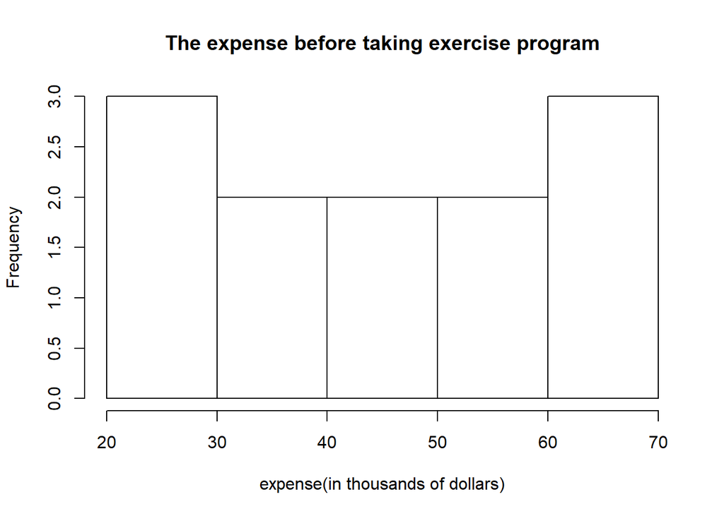

```r
hist(Before,xlab = "expense(in thousands of dollars)",main = "The expense before taking exercise program")
```

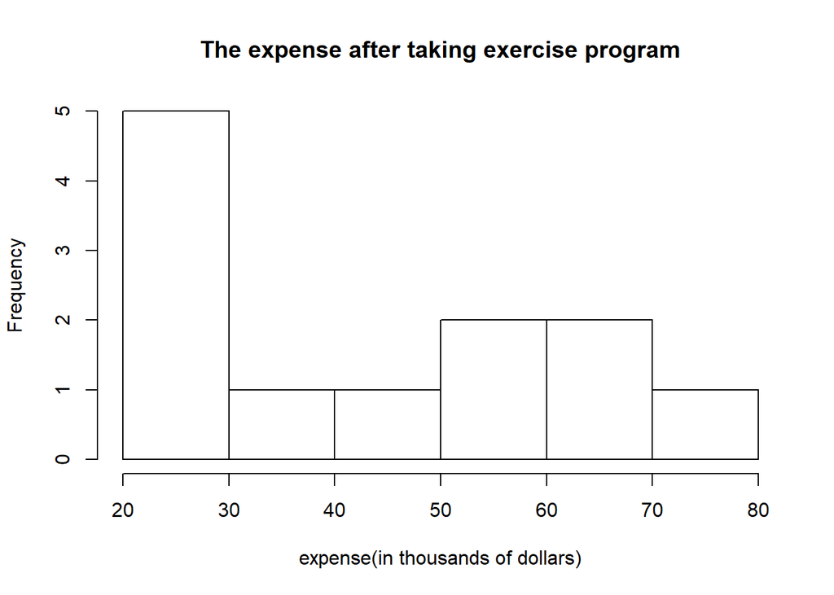

```r
hist(After,xlab = "expense(in thousands of dollars)",main = "The expense after taking exercise program")
```

```r
dif <- c()
for(i in c(1:length(Before))){

dif[i] <- After[i] - Before [i]

}
```

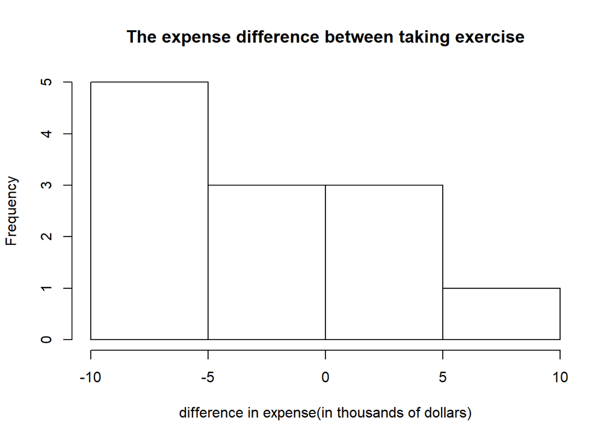

```r
his1392 <-hist(dif,xlab = "difference in expense(in thousands of dollars)",main = "The expense difference between taking exercise")
```

since the difference is non-normal, it is not appropriate to conduct a matched pairs experiment

# Exercise 13.96

The parameter tested is $\mu_D$ where $\mu_D$ = $\mu_1$ –$\mu_2$

$$H_0: \mu_D \geq 0$$

$$H_1: \mu_D < 0$$
since we want to know if it takes less money expense on insulated house

To decide which variance test we should use:

$$H_0: \sigma_1^2/\sigma_2^2 = 1$$

$$H_1: \sigma_1^2/\sigma_2^2 \neq 1$$

## a

```r
read1396 = read_excel(path = "D:\\Xr13-96.xlsx")
attach(read1396)
```

```r
ftest3 = var.test(Insulated,Uninsulated,alternative = "two.sided", conf.level = 0.9)
print(ftest3)
```

```
##
##  F test to compare two variances
##
## data:  Insulated and Uninsulated
## F = 1.0698, num df = 14, denom df = 14, p-value = 0.9013
## alternative hypothesis: true ratio of variances is not equal to 1
## 90 percent confidence interval:
##  0.430729 2.657121
## sample estimates:
## ratio of variances
##           1.069813
```

since p_value = 0.9013 > 0.05, there’s no sufficient evidence to infer that the population variances differ. It follows that we must apply the equal-variances t-test of $\mu_D$

```r
ttest3 = t.test(Insulated,Uninsulated,alternative = "less", mu = 0,paired = TRUE, var.equal = TRUE,conf.level = 0.90)
print(ttest3)
```

```
##
##  Paired t-test
##
## data:  Insulated and Uninsulated
## t = -16.917, df = 14, p-value = 5.131e-11
## alternative hypothesis: true difference in means is less than 0
## 90 percent confidence interval:
##       -Inf -52.83633
## sample estimates:
## mean of the differences
##                   -57.4
```

since p_value = 5.131e-11 <0.05, there is sufficient evidence to support that it takes less money expense on insulated house

## b

```r
test3_interval = t.test(Insulated,Uninsulated,alternative = "two.sided", mu = 0,paired = TRUE, var.equal = TRUE,conf.level = 0.95)
print(test3_interval)
```

```
##
##  Paired t-test
##
## data:  Insulated and Uninsulated
## t = -16.917, df = 14, p-value = 1.026e-10
## alternative hypothesis: true difference in means is not equal to 0
## 95 percent confidence interval:
##  -64.67724 -50.12276
## sample estimates:
## mean of the differences
##                   -57.4
```

According to the above, there is a 95% chance that the mean savings due to insulating the house are at the range of [50.12276 ,64.67724]

## c

The required condition for the use of the techniques in part(a) & part(b) depends on the normality of the differences;

```r
dif3 <- c()
for(j in c(1: length(Insulated))){
dif3[j] <- Uninsulated[j] - Insulated[j]

}
```

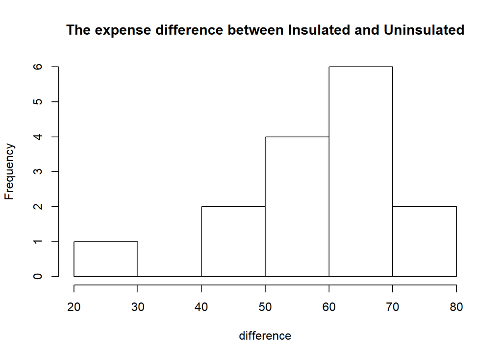

```r
hist(dif3,xlab = "difference" ,main = "The expense difference between Insulated and Uninsulated")
```

since the difference is normal, it is appropriate to conduct a matched pairs experiment

```r
zero_z <- function(p1, p2, p12, length1, length2){
  z = (p1-p2)/sqrt(p12*(1-p12)*(1/length1 + 1/length2))
  return(z)
}
```

# Exercise 13.130

To know whether customers who paid in regular price are more likely to buy an extended warranty

$$H_0: p_1 - p_2 = 0$$

$$H_0: p_1 - p_2 > 0$$

```r
p13130_1 =  47/229
p13130_2 =  25/178
p13130_mix = (47+25)/(229+178)

p13130_z = zero_z(p13130_1, p13130_2, p13130_mix, 229, 178)

cat("Since",p13130_z, ">", qnorm(0.9), " There is sufficient evidence to conclude at the 10% significance level, customers who paid in regular price are more likely to buy an extended warranty")
```

```
## Since 1.699218 > 1.281552  There is sufficient evidence to conclude at the 10% significance level, customers who paid in regular price are more likely to buy an extended warranty
```

# Exercise 13.156

To know whether including a reference to religious activity reduces the probability of a call back
$$H_0: p_1 - p_2 = 0$$

$$H_0: p_1 - p_2 < 0$$

```r
read13156 = read_excel(path = "D:\\Xr13-156.xlsx")
attach(read13156)
```

```r
length13156_1 = length(Religion)
length13156_2 = length(No_religion)


count13156_1 <- 0
count13156_2 <- 0
for(i in c(1:length13156_1) )
  {
  if(Religion[i] == 1)
    count13156_1 <- count13156_1 +1
    }
for(i in c(1:length13156_2) ){
  if(No_religion[i] == 1)
    count13156_2 <- count13156_2 +1
}

p13156_1 = count13156_1/length13156_1
p13156_2 = count13156_2/length13156_2
p13156_mix = (count13156_1+count13156_2) / (length13156_1+length13156_2)

p13156_z = zero_z(p13156_1, p13156_2, p13156_mix, length13156_1, length13156_2)
p13156_z = abs(p13156_z)

cat("Since",p13156_z, "<", qnorm(0.95), " There is insufficient evidence to conclude at the 5% significance level, including a reference to religious activity reduces the probability of a call back")
```

```
## Since 1.47442 < 1.644854  There is insufficient evidence to conclude at the 5% significance level, including a reference to religious activity reduces the probability of a call back
```

# Exercise 13A.13

To know whether people’s choice are affected by the attractiveness of opposite sex

```r
read13A13 = read_excel(path = "D:\\XrA13-13.xls")
attach(read13A13)
```

## a

since we hope to know if attractiveness will affect men’s decision
$$H_0: p_1 - p_2 = 0$$

$$H_0: p_1 - p_2 > 0$$

```r
length1313men_1 = length(Male_most)
length1313men_2 = length(Male_less)

count1313men_1 <- 0
count1313men_2 <- 0
for(i in c(1:length1313men_1) )
  {
  if(Male_most[i] == 2)
   count1313men_1 <- count1313men_1 +1
    }
for(i in c(1:length1313men_2) ){
  if(Male_less[i] == 2)
    count1313men_2 <- count1313men_2 +1
}

p1313men_1 = count1313men_1/length1313men_1
p1313men_2 = count1313men_2/length1313men_2
p1313men_mix = (count1313men_1+count1313men_2) / (length1313men_1+length1313men_2)

p1313men_z = zero_z(p1313men_1, p1313men_2, p1313men_mix, length1313men_1, length1313men_2)
p1313men_z = abs(p1313men_z)
value1313men = 1 - pnorm(p1313men_z)


cat("Since p_value",value1313men, "<", 0.05, " There is sufficient evidence to conclude at the 5% significance level, men's choice are affected by the attractiveness of women")
```

```
## Since p_value 0.009183719 < 0.05  There is sufficient evidence to conclude at the 5% significance level, men's choice are affected by the attractiveness of women
```

## a

since we hope to know if attractiveness will affect women’s decision
$$H_0: p_1 - p_2 = 0$$

$$H_0: p_1 - p_2 > 0$$

```r
length1313women_1 = length(Female_most)
length1313women_2 = length(Female_less)

count1313women_1 <- 0
count1313women_2 <- 0
for(i in c(1:length1313women_1) )
  {
  if(Female_most[i] == 2)
   count1313women_1 <- count1313women_1 +1
    }
for(i in c(1:length1313women_2) ){
  if(Female_less[i] == 2)
    count1313women_2 <- count1313women_2 +1
}

p1313women_1 = count1313women_1/length1313women_1
p1313women_2 = count1313women_2/length1313women_2
p1313women_mix = (count1313women_1+count1313women_2) / (length1313women_1+length1313women_2)

p1313women_z = zero_z(p1313women_1, p1313women_2, p1313women_mix, length1313women_1, length1313women_2)
p1313women_z = abs(p1313women_z)
value1313women = 1 - pnorm(p1313women_z)


cat("Since p_value",value1313women, ">", 0.05, " There is insufficient evidence to conclude at the 5% significance level, women's choice are affected by the attractiveness of men")
```

```
## Since p_value 0.3093783 > 0.05  There is insufficient evidence to conclude at the 5% significance level, women's choice are affected by the attractiveness of men
```